# Los Angeles AirBnb Calender Analysis

## Note:

## The CSV files read in this document are the result of the code ran on EMR, which is placed in this same direcoty as python file and ipynb file with name calendar_analysis_emr

```python
from matplotlib import pyplot as plt
import pandas as pd
import seaborn as sns
import numpy as np

%matplotlib inline
sns.set_style("darkgrid")
```

```python
root_folder = "../processed_data/calendar_data/"

year_month_avg_price = root_folder + "year_month_avg_price_1.csv"
day_avg_price = root_folder + "day_avg_price_2.csv"
holiday_avg_price = root_folder + "holiday_avg_price_3.csv"
holiday_total_listings = root_folder + "holiday_total_listings_4.csv"
avg_2019_july = root_folder + "avg_2019_july_5.csv"
avg_2019_dec = root_folder + "avg_2019_dec_6.csv"
```

# Analyze and understand how the price of AirBnb listings in Los Angles changes with respsective to differen seasons, Holidays, Month and Weekdays

#### To analyse for above question lets break the problem in to following smaller questions¶

## How the average price of the listings vary with different months in the year 2019?

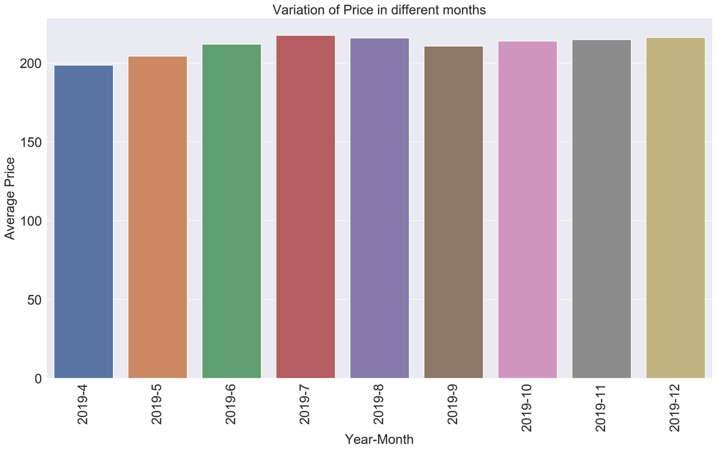

```python
year_month_avg_price_df = pd.read_csv(year_month_avg_price)
year_month_avg_price_df = year_month_avg_price_df.sort_values(by=['year','month'], ascending=True)

x_objects = year_month_avg_price_df['year-month']
y_objects = year_month_avg_price_df['average_price']

plt.figure(figsize=(18,10), dpi=200)
ax = sns.barplot(x= x_objects, y= y_objects, palette="deep")
ax.tick_params(labelsize=20)
plt.xticks(rotation=90)
plt.title("Variation of Price in different months",fontsize=20)
plt.ylabel('Average Price',fontsize=20)
plt.xlabel('Year-Month',fontsize=20)
```

It can be seen from the above bar chart that in the month of July(2019-7) and December(2019-12) Average price for the listing is maximum.But we need to see why it's so, lets explore more now

## How does the average price of listings vary in 7 days of week?

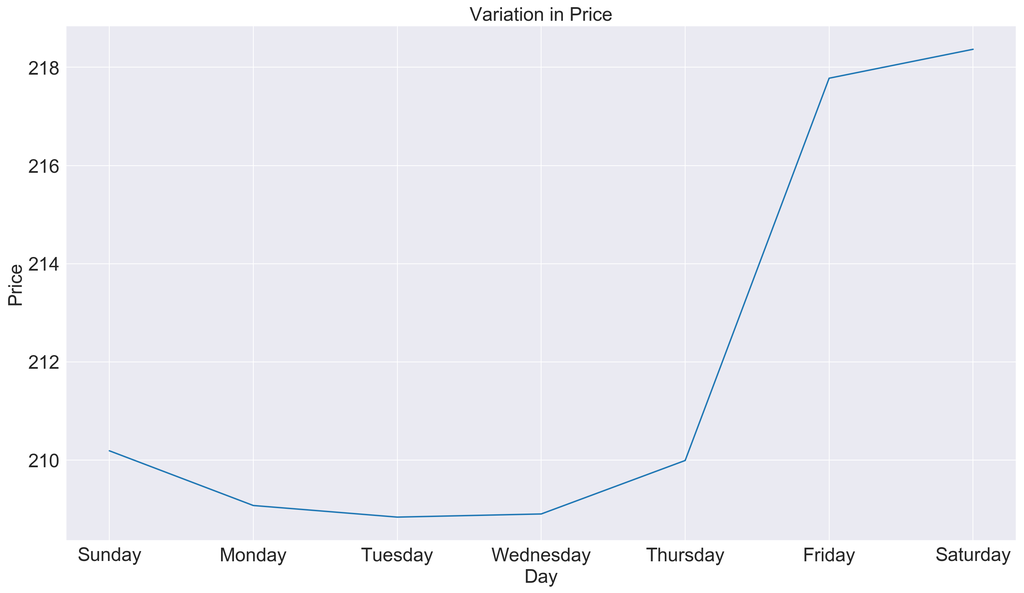

```python
day_avg_price_df = pd.read_csv(day_avg_price)
day_avg_price_df

days = [ 'Sunday','Monday', 'Tuesday', 'Wednesday', 'Thursday', 'Friday', 'Saturday']
day_avg_price_df['day_name'] = day_avg_price_df['day_name'].astype('category', categories=days, ordered=True)


plt.figure(figsize=(18,10), dpi=200)
ax = sns.lineplot(x="day_name", y="average_price",data=day_avg_price_df)
ax.tick_params(labelsize=20)
# Add titles
plt.title("Variation in Price",fontsize=20)
plt.xlabel("Day",fontsize=20)
plt.ylabel("Price",fontsize=20)
plt.show()
```

From this graph its clear that Fridat and Saturday the Price of Houses in AirBnB will be more compared to other week days. Saturdays is is maximum among all.

## How does the average price of listings vary in US holidays?

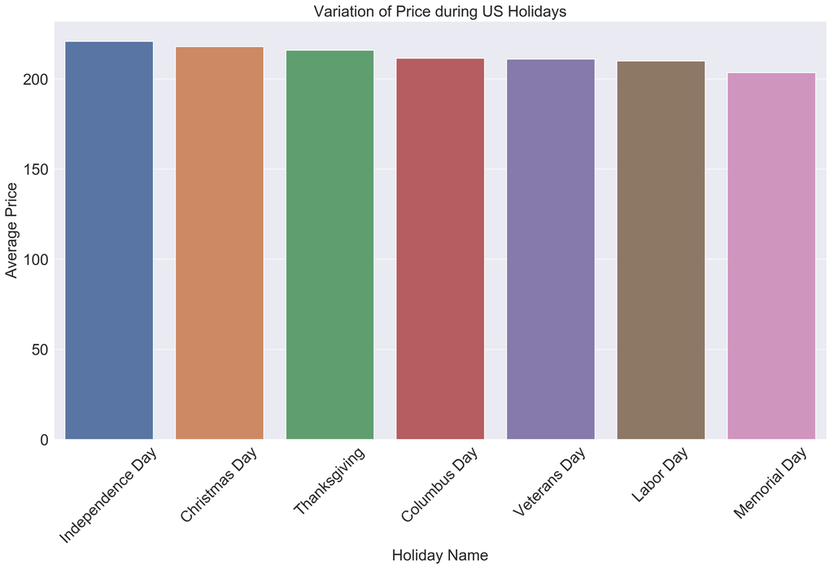

```python
holiday_avg_price_df = pd.read_csv(holiday_avg_price)
holiday_avg_price_df = holiday_avg_price_df.sort_values(by=['average_price'], ascending=False)


x_objects = holiday_avg_price_df['holiday_name']
y_objects = holiday_avg_price_df['average_price']

plt.figure(figsize=(18,10), dpi=200)
ax = sns.barplot(x= x_objects, y= y_objects, palette="deep")
ax.tick_params(labelsize=20)
plt.xticks(rotation=45)
plt.title("Variation of Price during US Holidays",fontsize=20)
plt.ylabel('Average Price',fontsize=20)
plt.xlabel('Holiday Name',fontsize=20)
```

During Independence Day and Christmas day it happends to be Maximum average price. When we check the dates of Independence day its on July 4th and Christmas Day is on December 25th  
Now we know why is high price in the month of July and December. Now lets dig deep.

## How does total number of listings vary with US holidays?

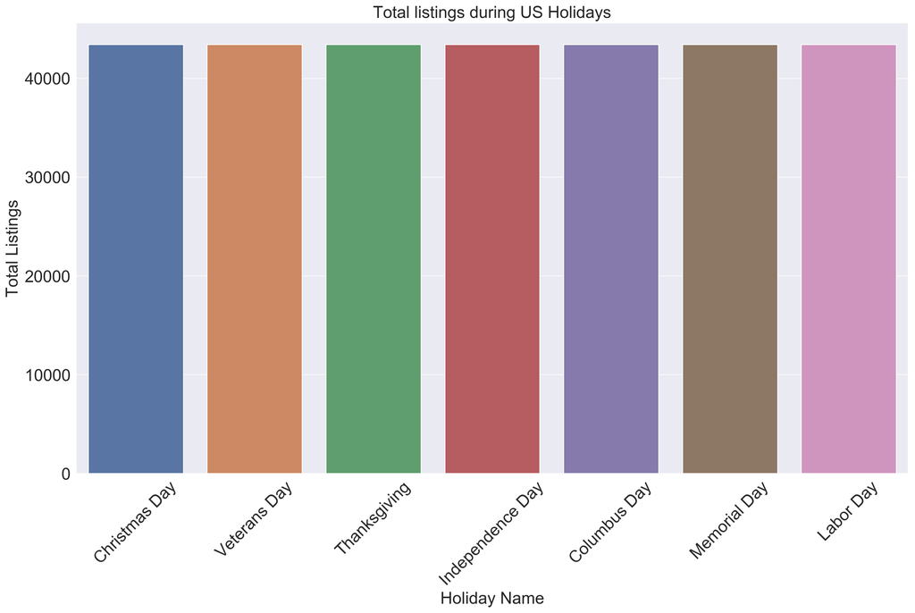

```python
holiday_total_listings_df = pd.read_csv(holiday_total_listings)
holiday_total_listings_df.dropna(inplace=True)
holiday_total_listings_df = holiday_total_listings_df.sort_values(by=['total_listing'], ascending=False)


x_objects = holiday_total_listings_df['holiday_name']
y_objects = holiday_total_listings_df['total_listing']

plt.figure(figsize=(18,10), dpi=200)
ax = sns.barplot(x= x_objects, y= y_objects, palette="deep")
ax.tick_params(labelsize=20)
plt.xticks(rotation=45)
plt.title("Total listings during US Holidays",fontsize=20)
plt.ylabel('Total Listings',fontsize=20)
plt.xlabel('Holiday Name',fontsize=20)
```

This graph shows number of listings doesnt vary with the holodays.Its almost same.

## July, 2019 Average listing price changes

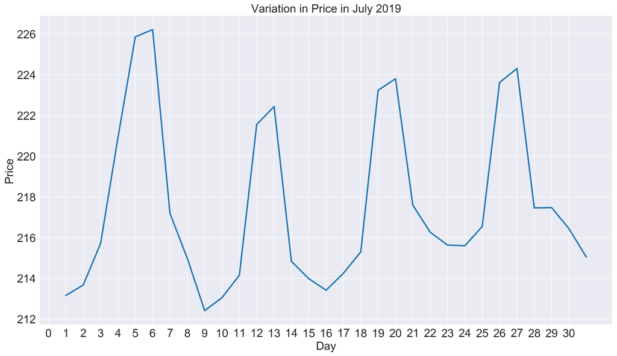

```python
avg_2019_july_df = pd.read_csv(avg_2019_july)
avg_2019_july_df


plt.figure(figsize=(18,10), dpi=200)
sns.set_context(font_scale=2.5, rc={"lines.linewidth": 2.5})
sns.set_style("darkgrid")
ax = sns.lineplot(x="dayofmonth", y="average_price",data=avg_2019_july_df)
ax.set_xticks(range(31))
ax.tick_params(labelsize=20)
# Add titles
plt.title("Variation in Price in July 2019", fontsize=20)
plt.xlabel("Day",fontsize=20)
plt.ylabel("Price",fontsize=20)
plt.show()
```

This graph show how the price varies in the month of July.

- Every weeked the price is more.
- In July, the 1st weekend which is long weekend with a holiday in middle(July 4th) we found higest price.

## December, 2019 Average listing price changes

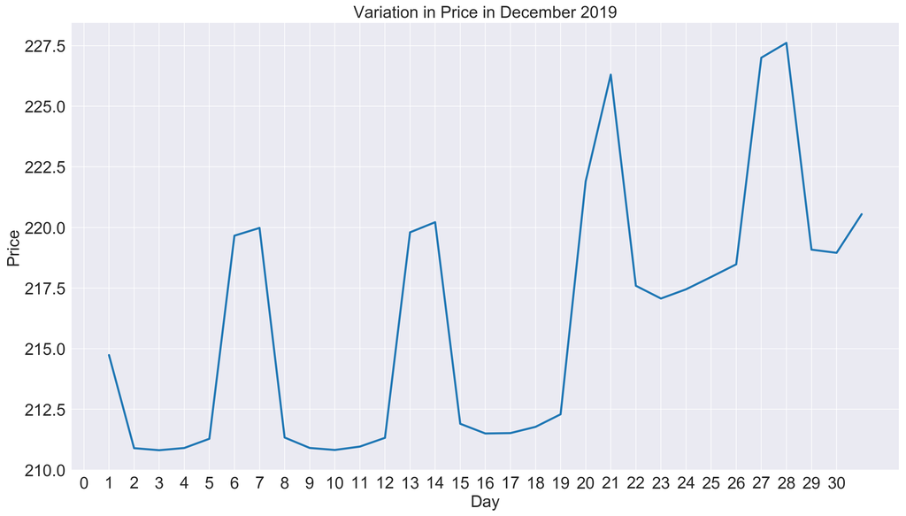

```python
avg_2019_dec_df = pd.read_csv(avg_2019_dec)

plt.figure(figsize=(18,10), dpi=200)
sns.set_context(font_scale=2.5, rc={"lines.linewidth": 2.5})
sns.set_style("darkgrid")
ax = sns.lineplot(x="dayofmonth", y="average_price",data=avg_2019_dec_df)
ax.set_xticks(range(31))
ax.tick_params(labelsize=20)
# Add titles
plt.title("Variation in Price in December 2019", fontsize=20)
plt.xlabel("Day",fontsize=20)
plt.ylabel("Price",fontsize=20)
plt.show()
```

This graph show how the price varies in the month of December.

- Every weeked the price is more, and price keeps incresing in the weekends till the end of month.
- In December, the last weekend which is long weekend with a holiday on December 25th we found higest price.

### Conclussion

- In weekdends the house price increses.
- In US holidays or Long weekends the price is more compared to other days.